# HW7 -Chapter8.Tree-Based Methods

### Bagging and Random Forests

```r
### Bagging ### randomforest에서 m =p
set.seed(1)
# mtry= 13
bag.boston = randomForest(medv~., data = Boston, subset = train_index, mtry=13, importance=TRUE)
          # mtry=13 의미 : 트리의 각 split에 13개 variable 이 모두 고려된다는 의미
bag.boston
```

```
##
## Call:
##  randomForest(formula = medv ~ ., data = Boston, mtry = 13, importance = TRUE,      subset = train_index)
##                Type of random forest: regression
##                      Number of trees: 500
## No. of variables tried at each split: 13
##
##           Mean of squared residuals: 11.15723
##                     % Var explained: 86.49
```

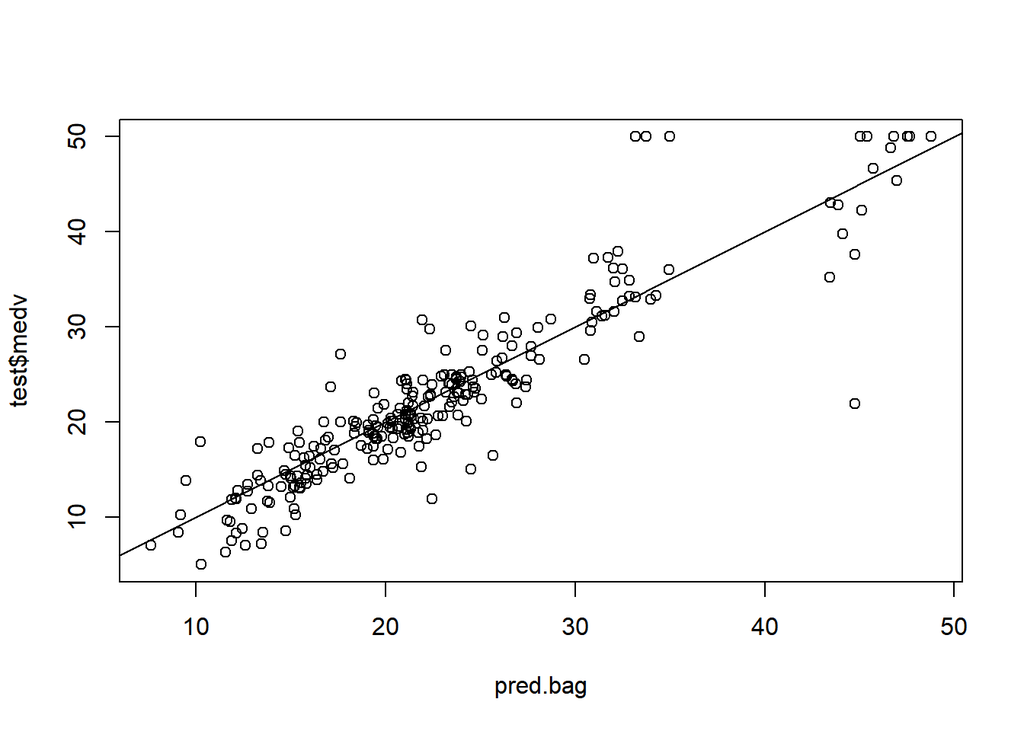

```r
pred.bag= predict(bag.boston, test)
plot(pred.bag, test$medv)
abline(0,1)
```

```r
mean((pred.bag-test$medv)^2) # single tree사용했을 때의 절반!
```

```
## [1] 13.50808
```

```r
# mtry= 13, ntree= 25
bag.boston1 = randomForest(medv~., data = Boston, subset = train_index, mtry=13, ntree=25, importance=TRUE)
bag.boston1
```

```
##
## Call:
##  randomForest(formula = medv ~ ., data = Boston, mtry = 13, ntree = 25,      importance = TRUE, subset = train_index)
##                Type of random forest: regression
##                      Number of trees: 25
## No. of variables tried at each split: 13
##
##           Mean of squared residuals: 13.88799
##                     % Var explained: 83.18
```

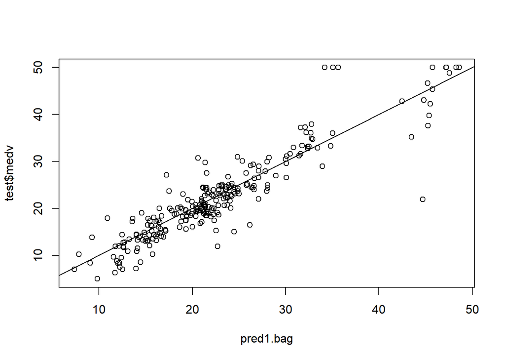

```r
pred1.bag= predict(bag.boston1, test)
plot(pred1.bag, test$medv)
abline(0,1)
```

```r
mean((pred1.bag-test$medv)^2) # single tree사용했을 때의 절반!
```

```
## [1] 13.66237
```

```r
### Random Forest ###
set.seed(1)
rf.boston = randomForest(medv~., data = Boston, subset = train_index, mtry= 6, importance=TRUE)
           # 일반적으로 regression tree 만들 떄는 p/3개 사용
           # classification tree 만들떄는 sqrt(p)개 사용
rf.boston
```

```
##
## Call:
##  randomForest(formula = medv ~ ., data = Boston, mtry = 6, importance = TRUE,      subset = train_index)
##                Type of random forest: regression
##                      Number of trees: 500
## No. of variables tried at each split: 6
##
##           Mean of squared residuals: 11.8888
##                     % Var explained: 85.6
```

```r
pred.rf = predict(rf.boston, newdata= test)
mean((pred.rf-test$medv)^2) # test MSE -> rf가 bagging 보다 더 good!
```

```
## [1] 11.66454
```

```r
importance(rf.boston) # 변수중요도에 대해서 %IncMSE , IncNodePurity값 제공
```

```
##           %IncMSE IncNodePurity
## crim    12.132320     986.50338
## zn       1.955579      57.96945
## indus    9.069302     882.78261
## chas     2.210835      45.22941
## nox     11.104823    1044.33776
## rm      31.784033    6359.31971
## age     10.962684     516.82969
## dis     15.015236    1224.11605
## rad      4.118011      95.94586
## tax      8.587932     502.96719
## ptratio 12.503896     830.77523
## black    6.702609     341.30361
## lstat   30.695224    7505.73936
```

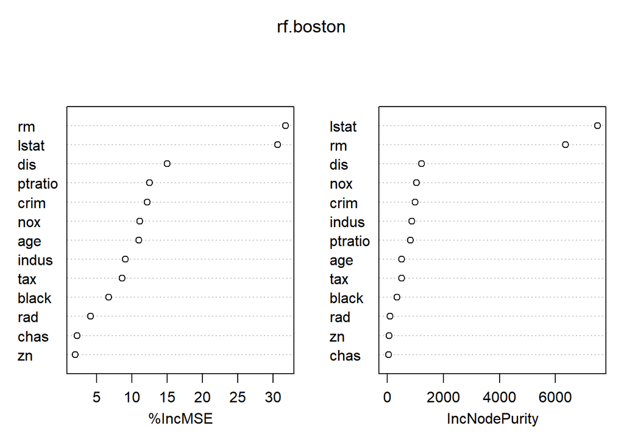

```r
varImpPlot(rf.boston)
```

* 변수 중요도에 대한 두 가지 측도 - %IncMSE :해당 변수가 모델에서 제외될 떄 bagging 되지 않은 sample에 대한 예측정확도의 평균감소량 - IncNodePurity :해당 변수에 대한 분할로 인한 노드 impurity의 총 감소량에 대해 모든 트리들의 평균값

### Boosting

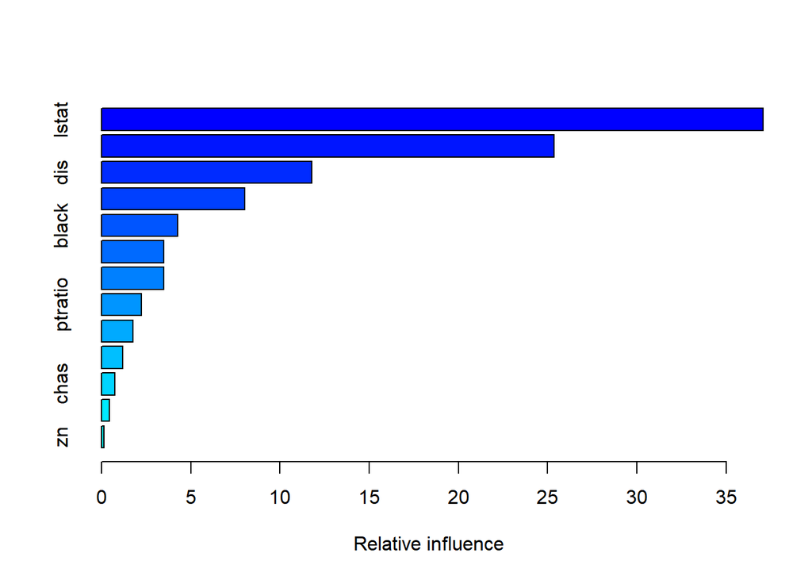

```
##             var    rel.inf
## lstat     lstat 37.0661275
## rm           rm 25.3533123
## dis         dis 11.7903016
## crim       crim  8.0388750
## black     black  4.2531659
## nox         nox  3.5058570
## age         age  3.4868724
## ptratio ptratio  2.2500385
## indus     indus  1.7725070
## tax         tax  1.1836592
## chas       chas  0.7441319
## rad         rad  0.4274311
## zn           zn  0.1277206
```

```r
library(gbm)
## model fitting
set.seed(1)
boost.boston = gbm(medv~., data = Boston[train_index,], distribution = "gaussian", n.trees= 5000,
                   interaction.depth = 4) # shirinkage default = 0.001
# shirinkage para lambda 조정
set.seed(1)
boost.boston.adj = gbm(medv~., data = Boston[train_index,], distribution = "gaussian", n.trees= 5000,
                   interaction.depth = 4, shrinkage = 0.2, verbose=F)
summary(boost.boston)
```

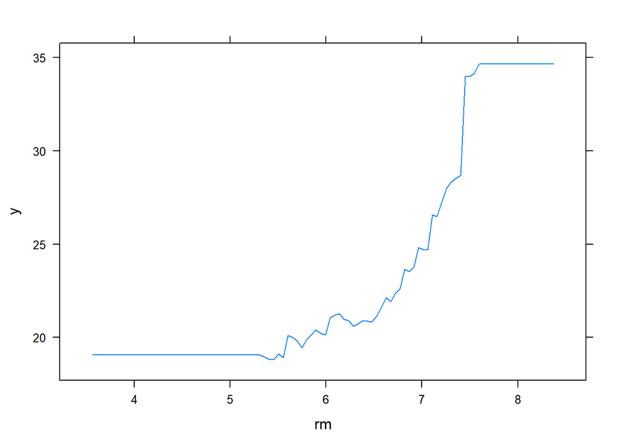

```r
## Partial Dependence Plot (부분종속성그래프)
par(mfrow=c(1,2))
plot(boost.boston, i = "rm")
```

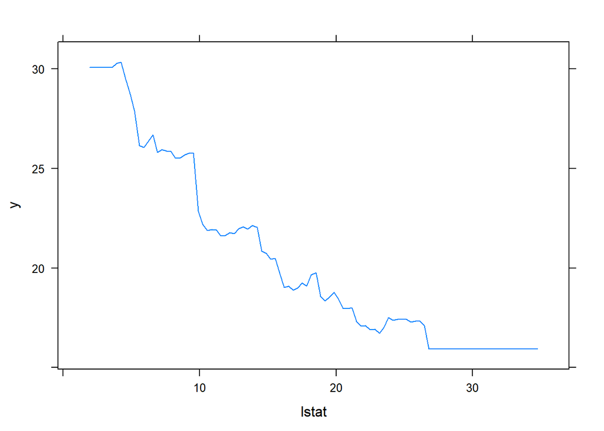

```r
plot(boost.boston, i = "lstat")
```

```r
par(mfrow=c(1,1))

## predict - > test MSE
pred.boost = predict(boost.boston, newdata=test, n.trees = 5000)
pred.boost.adj = predict(boost.boston.adj, newdata=test, n.trees = 5000)

# testMSE
mean((pred.boost-test$medv)^2) # test MSE , rf와비슷, bagging보다 우수함
```

```
## [1] 10.81479
```

```r
mean((pred.boost.adj-test$medv)^2)
```

```
## [1] 12.14053
```

- distribution = “gaussian”, 만약 2-class 분류문제였다면 “bernouli”로 지정
- n.trees= 5000 : 트리의 수
- interaction.depth: 트리의 깊이
- summary 결과 :lstat가 가장 중요한 변수
- partial dependence plot : rm 이 증가할수록 주택가격의median증가, lstat 증가할수록 주택각격의median 감소

### EX 8

```r
library(ISLR)
#a
data(Carseats)
set.seed(1)
train_index= sample(1:nrow(Carseats), nrow(Carseats)/2)
test = Carseats[-train_index,]

#b
tree.carseats = tree(Sales~., data= Carseats,subset =train_index)
pred.tree = predict(tree.carseats, test)
summary(tree.carseats)
```

```
##
## Regression tree:
## tree(formula = Sales ~ ., data = Carseats, subset = train_index)
## Variables actually used in tree construction:
## [1] "ShelveLoc"   "Price"       "Age"         "Advertising" "Income"
## [6] "CompPrice"
## Number of terminal nodes:  18
## Residual mean deviance:  2.36 = 429.5 / 182
## Distribution of residuals:
##    Min. 1st Qu.  Median    Mean 3rd Qu.    Max.
## -4.2570 -1.0360  0.1024  0.0000  0.9301  3.9130
```

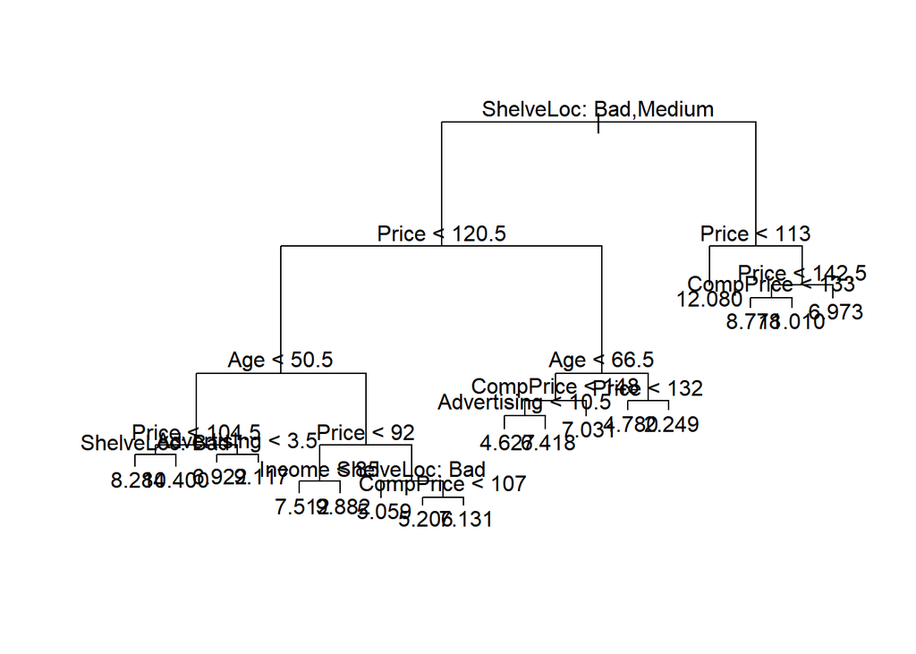

```r
# tree plot
plot(tree.carseats)
text(tree.carseats, pretty=0)
```

```r
# testMSE
mean((pred.tree - test$Sales)^2)
```

```
## [1] 4.148897
```

```r
#c
#model fitting
cv.carseats = cv.tree(tree.carseats, FUN = prune.tree)
cv.carseats
```

```
## $size
##  [1] 18 17 16 15 14 12 11 10  9  8  7  6  5  4  3  1
##
## $dev
##  [1] 1094.537 1085.178 1089.409 1069.294 1069.294 1075.806 1044.469
##  [8] 1039.212 1039.212 1041.308 1043.459 1064.162 1119.046 1120.344
## [15] 1270.012 1560.273
##
## $k
##  [1]      -Inf  15.48181  15.53599  18.69038  18.74886  21.05038  23.79480
##  [8]  25.78579  26.01210  30.10435  32.74801  53.28569  72.33061  78.19599
## [15] 141.73781 251.22901
##
## $method
## [1] "deviance"
##
## attr(,"class")
## [1] "prune"         "tree.sequence"
```

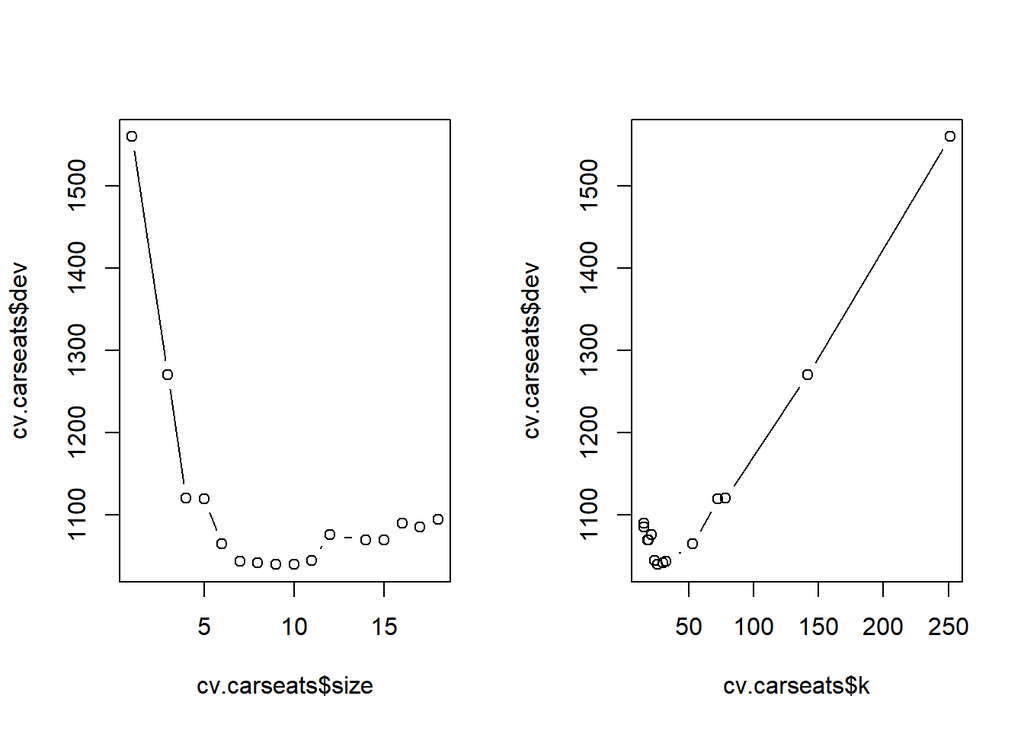

```r
#plot -> best size =9
par(mfrow = c(1, 2))
plot(cv.carseats$size, cv.carseats$dev, type = "b")
plot(cv.carseats$k, cv.carseats$dev, type = "b")
```

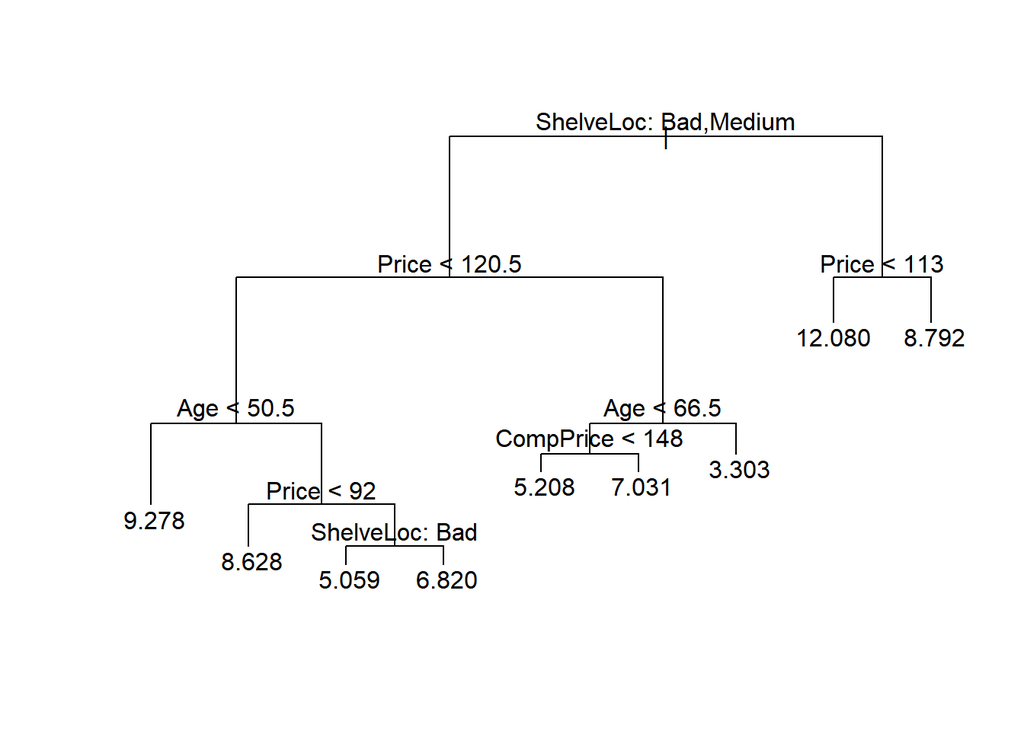

```r
par(mfrow = c(1, 1))
# pruning
pruned.carseats = prune.tree(tree.carseats, best = 9)
plot(pruned.carseats)
text(pruned.carseats, pretty = 0)
```

```r
# predict
pred.prune = predict(pruned.carseats, test)
mean((pred.prune-test$Sales)^2)
```

```
## [1] 4.993124
```

```r
#d
library(randomForest)
## bagging model fitting
bag.carseats = randomForest(Sales~.,data =Carseats, subset=train_index, mtry=ncol(Carseats)-1,ntree=500, importance =TRUE)
bag.carseats
```

```
##
## Call:
##  randomForest(formula = Sales ~ ., data = Carseats, mtry = ncol(Carseats) -      1, ntree = 500, importance = TRUE, subset = train_index)
##                Type of random forest: regression
##                      Number of trees: 500
## No. of variables tried at each split: 10
##
##           Mean of squared residuals: 2.811039
##                     % Var explained: 63.17
```